# Assessment 3

52414

April 22nd, 2020

## Assessment 3:

1. Write a function that recieves as input two vectors of real numbers: a and x. The function should return a vector e of the same length as a, such that e(i) is the empirical cumulative distribtuion function of the sample x, evaluated at the point a(i), that is $e(i) = \hat{F}_n(a(i))$ where $\hat{F}_n$ is the empirical CDF defined by $x$.  
   **Solution:**

```r
my_ecdf <- function(a, x){
  e <- rep(0,length(a))
  or_a <- a[order(a)]
  or_x <- x[order(x)]
  for (j in 1:length(a)) {
    for (i in 1:length(x)) {
      if (or_x[i]<= or_a[j]) {
        e[j]<-e[j]+1
      }
    }
    e[j]<- e[j]/length(x)
  }
  return(e)
}
```

2. Download from moodle and load the Israeli crime dataset. Calculate the assaults-rate: assaults per 1000 people for each city in the Israeli crime dataset. Make a figure showing the empirical CDF of the assults-rate in each of the four regions in Israel (one plot, 4 different curves of different colors, each representing a different region). You can use the function from question 1 or other commands in R.  
   **Solution:**

```r
rm(list=ls())
library(tidyverse)
crimes = read.csv("C:/Users/איתי חדש/Desktop/itayhadash/R/עבודות/israeli_crime_2011_region.csv",stringsAsFactors = FALSE)
names(crimes)[5] <- "population"
cases_per1000 <- round((crimes$assaults/crimes$population)*1000,4)
cases_per1000 <- as.data.frame(cases_per1000)
crimes <-cbind(crimes,cases_per1000)
names(crimes)[6]<- "assaults per 1000"
a<- c(seq(1,10,0.5))
rige <- crimes %>% group_by(region) %>% select(`assaults per 1000`)
```

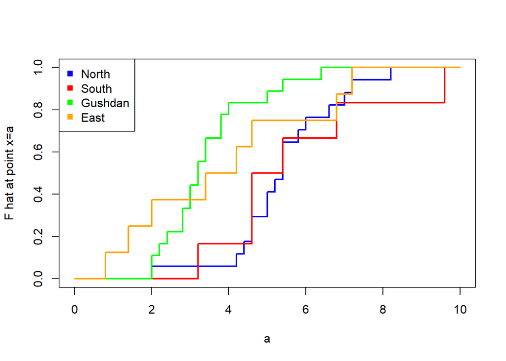

```r
North <- rige[which(rige$region == "North"),]
South <- rige[which(rige$region == "South"),]
GushDan <- rige[which(rige$region == "GushDan"),]
East <- rige[which(rige$region == "East"),]

a <- c(seq(0,10,by=0.2))
my_ecdf <- function(a, x){
  e <- rep(0,length(a))
  or_a <- a[order(a)]
  or_x <- x[order(x)]
  for (j in 1:length(a)) {
    for (i in 1:length(x)) {
      if (or_x[i]<= or_a[j]) {
        e[j]<-e[j]+1
      }
    }
    e[j]<- e[j]/length(x)
  }
  return(e)
}

#heights %>% filter(sex=="Male") %>% ggplot(aes(height)) +
  #stat_ecdf() +
  #ylab(expression("hat(F) n(a)")) + xlab("a")
plot(a,my_ecdf(a,North$`assaults per 1000`),type = "S",col="blue",lwd =2,ylab = "F hat at point x=a")
lines(a,my_ecdf(a,South$`assaults per 1000`),type ="S",col="red",lwd =2)
lines(a,my_ecdf(a,GushDan$`assaults per 1000`),type = "S",col="green",lwd =2 )
lines(a,my_ecdf(a,East$`assaults per 1000`),type = "S",col="orange",lwd =2)
legend("topleft",c("North","South","Gushdan","East"),col = c("blue","red","green","orange"),pch = 15)
```

3. Make a figure with histogram plot for the assaults rate in the North region. Choose bin size approriate for the data.

Next, make another figure with a single smoothed density plot showing the densities of the four regions of the same data as in qu. 2 (with four different colors). What can you conclude about the differences between the regions?  
**Solution:**

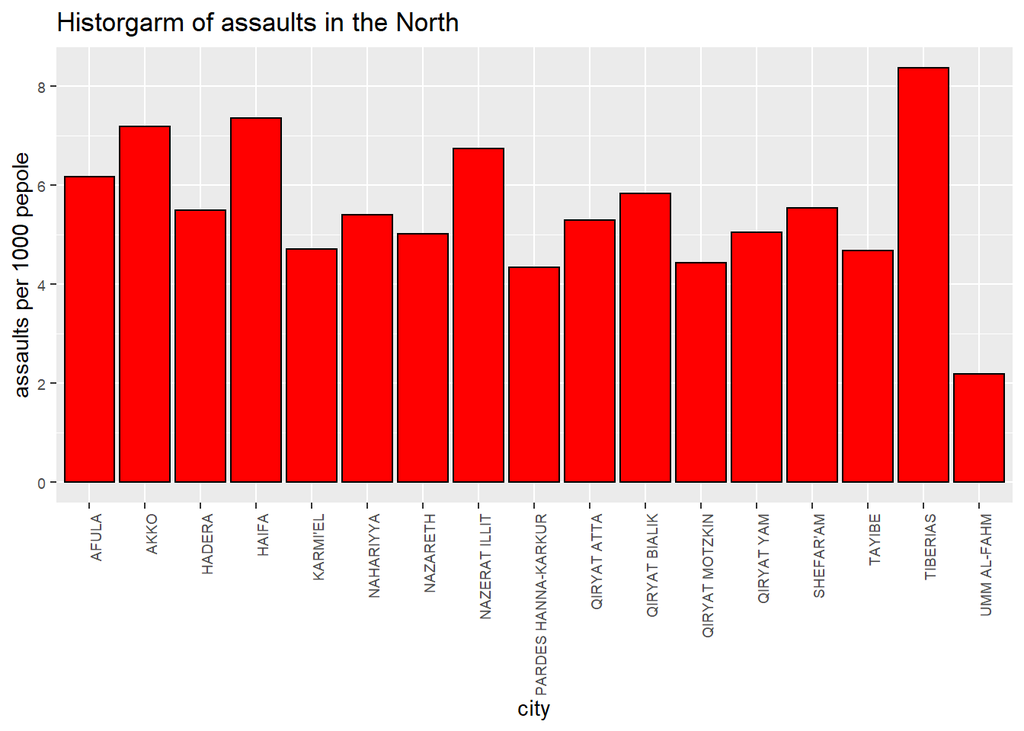

```r
library("ggplot2")
nor <- crimes %>% filter(region=="North")
nor[c(1,6)] %>% ggplot(mapping = aes(town,`assaults per 1000`))  + geom_histogram(stat = "identity",fill ="red",color ="black",) + theme(axis.text = element_text(size = 7)) + theme(axis.text.x = element_text(angle = 90, hjust = 1)) + labs(title = "Historgarm of assaults in the North",x ="city", y="assaults per 1000 pepole")
```

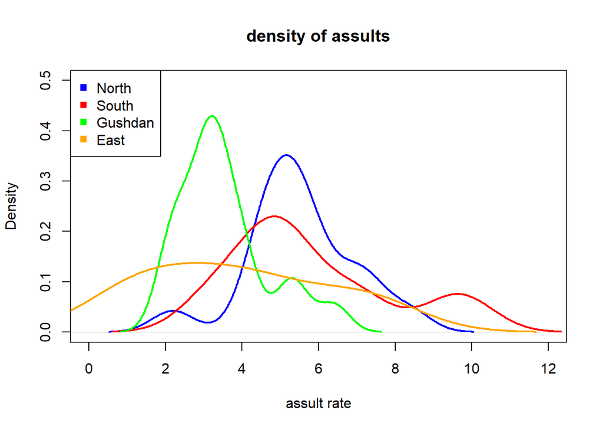

```r
plot(density(North$`assaults per 1000`),ylim=c(0,0.5),xlim = c(0,12),col ="blue",lwd = 2,main = "density of assults",xlab = "assult rate")
lines(density(South$`assaults per 1000`),col="red", lwd = 2)
lines(density(GushDan$`assaults per 1000`),col ="green", lwd = 2)
lines(density(East$`assaults per 1000`), col= "orange", lwd = 2)
legend("topleft",c("North","South","Gushdan","East"),col = c("blue","red","green","orange"),pch = 15)
```